# Linear Regression - Predicting Individual Medical Costs Billed by Health Insurance

4/18/2020

Lealena Befikadu

## Exploratory Data Analysis

While analyzing the “insurance.csv” dataset, I found there to be 1338 observations and 7 variables. The categorical variables in the dataset are: sex (insurance contractor gender), smoker (smoking status), region (beneficiary’s residential area), and children (number of dependents). For the sex variable, the highest percentage was male with 50.5%. For the smoker variable, the highest percentage was no (or don’t smoke) with 79.5%. For the region variable, the highest percentage was southeast with 27.2%. For the children variable, the highest percentage was 0 number of children covered by health insurance/number of dependents with 42.9%. The continuous variables in the dataset are: age, bmi, and charges. The mean for age is 39.2 with a standard deviation of 14.0. The mean for bmi is 30.7 with a standard deviation of 6.1. The mean for individual medical costs billed by health insurance is 13270.4 with a standard deviation of 12110.0.

```r
# insert import & exploratory data analysis code here
#call libraries
library(ggplot2)
library(dplyr)
library(tidyr)
library(tidyverse)

#set working directory
setwd("/Users/lealenabefikadu/Downloads")
#read file
insure <- read.csv("insurance.csv", header = TRUE)

#num of observations
nrow(insure)
```

```
## [1] 1338
```

```r
#num of variables
ncol(insure)
```

```
## [1] 7
```

```r
#categorical variables percentages
round(prop.table(table(insure$sex))*100, digit = 1)
```

```
##
## female   male
##   49.5   50.5
```

```r
round(prop.table(table(insure$smoker))*100, digit = 1)
```

```
##
##   no  yes
## 79.5 20.5
```

```r
round(prop.table(table(insure$region))*100, digit = 1)
```

```
##
## northeast northwest southeast southwest
##      24.2      24.3      27.2      24.3
```

```r
round(prop.table(table(insure$children))*100, digit = 1)
```

```
##
##    0    1    2    3    4    5
## 42.9 24.2 17.9 11.7  1.9  1.3
```

```r
#continuous variables mean and sd
round(mean(insure$age), digit = 1)
```

```
## [1] 39.2
```

```r
round(mean(insure$bmi), digit = 1)
```

```
## [1] 30.7
```

```r
round(mean(insure$charges), digit = 1)
```

```
## [1] 13270.4
```

```r
round(sd(insure$age), digit = 1)
```

```
## [1] 14
```

```r
round(sd(insure$bmi), digit = 1)
```

```
## [1] 6.1
```

```r
round(sd(insure$charges), digit = 1)
```

```
## [1] 12110
```

## Data Visualization

For Figure 1, the box plot of health insurance charges by insurance contractor gender shows a slightly higher median in the average individual medical costs billed by health insurance for females than males.

For Figure 2, the box plot of health insurance charges by smoking status shows a subtantially higher median in the average individual medical costs billed by health insurance for individuals who smoke than for individuals who do not smoke

For Figure 3, the box plot of health insurance charges by the beneficiary’s residential area shows a slightly higher median in average individual medical costs billed by health insurance for beneficiaries who live in the northeast region than beneficiaries in the northwest, southeast, and southwest regions.

For Figure 4, the box plot of health insurance charges by number of children covered by health insurance shows a slightly higher median in average individual medical costs billed by health insurance for 4 number of children that are covered by health insurance than for another other number of dependents.

For Figure 6, the scatterplot of age of primary beneficiary and health insurance charges shows that there is no set charge for each age but it also shows a somewhat positive correlation between age of primary beneficiary and the average individual medical costs billed by health insurance.

**Figure 1**

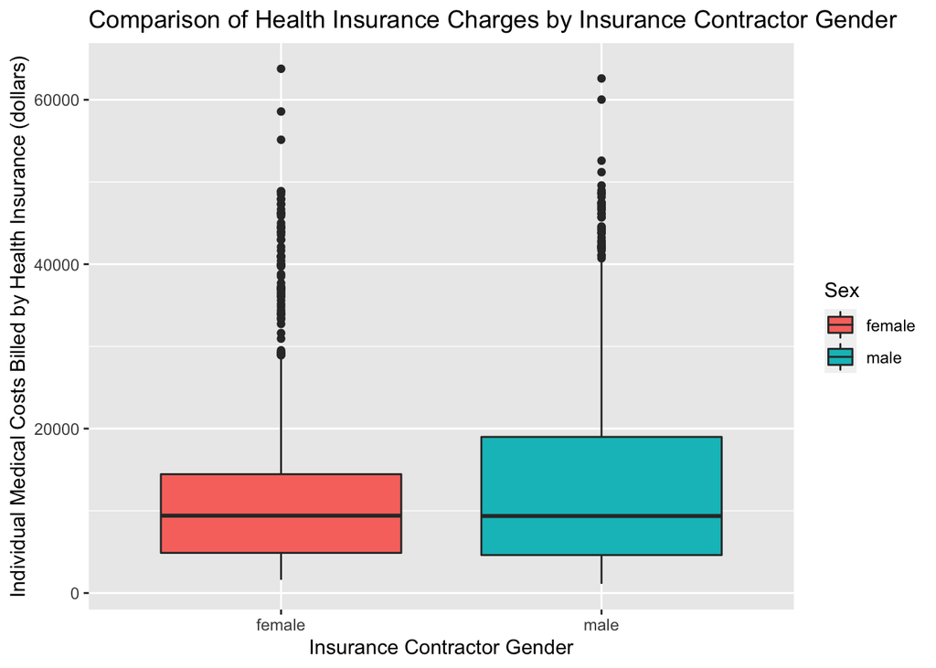

**Figure 2**

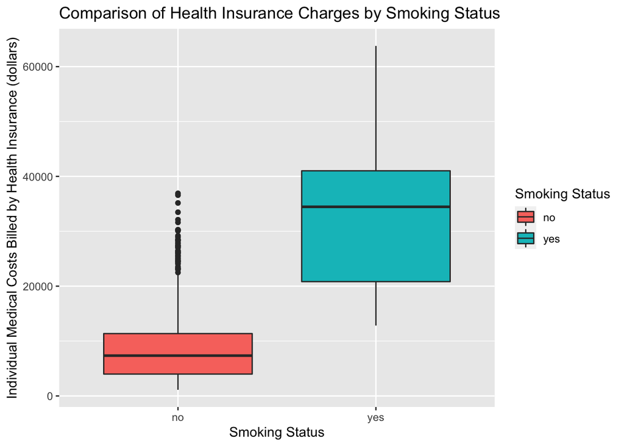

**Figure 3**

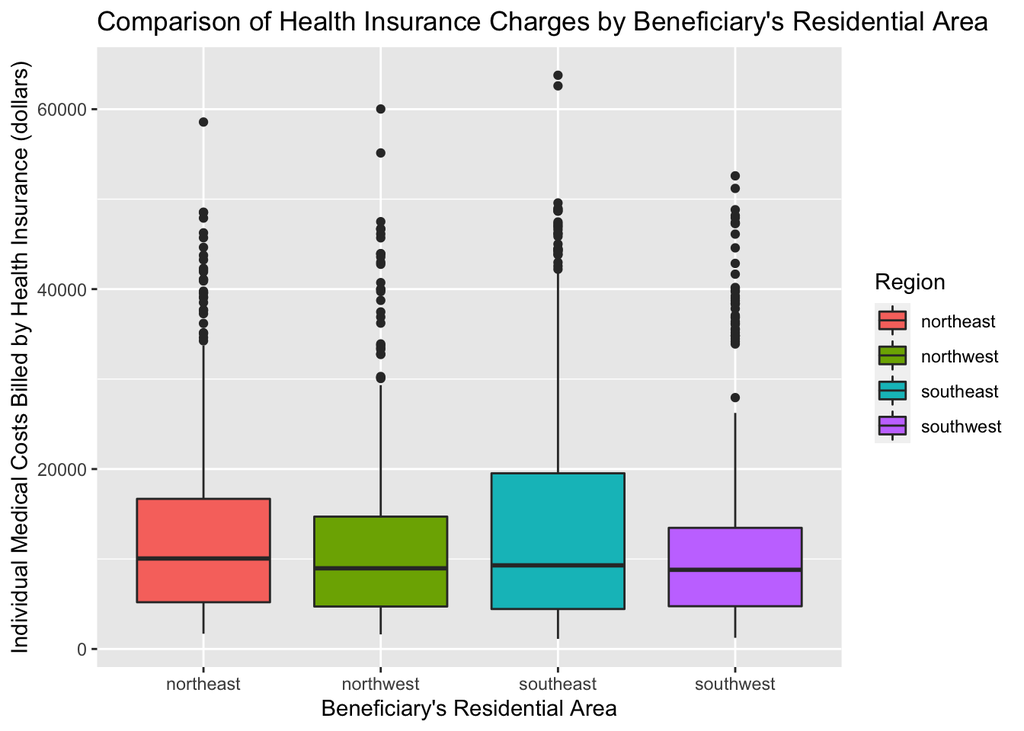

**Figure 4**

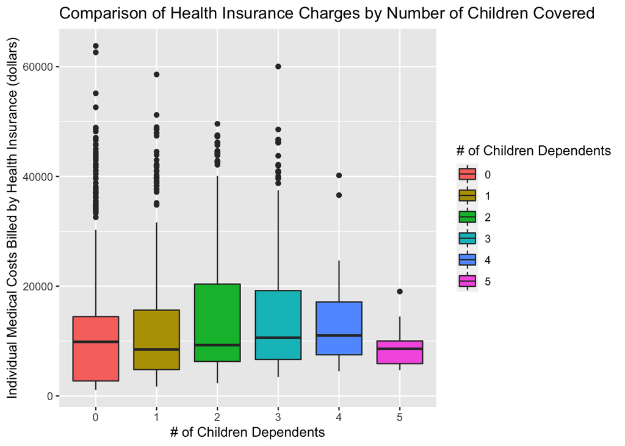

**Figure 5**

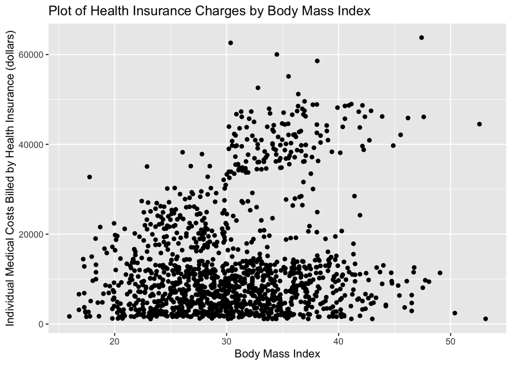

**Figure 6**

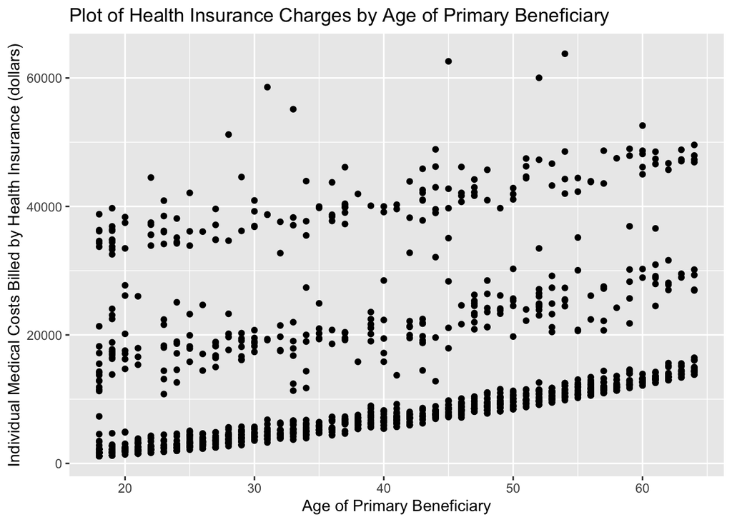

## Multiple Linear Regression Results

We ran a multiple linear regression model on the dataset and found that: For a 1 year increase in age of primary beneficiary, the average individual medical costs billed by health insurance increases by an average 257.2 dollars, holding all other variables in the model constant. For a 1 unit increase in bmi, the average individual medical costs billed by health insurance increases by an average 336.9 dollars, holding all other variables in the model constant. The average individual medical costs billed by health insurance is 128.2 dollars lower in males than females, holding all other variables in the model constant. The average individual medical costs billed by health insurance is 23836.4 dollars higher in individuals who smoke than individuals who do not smoke, holding all other variables in the model constant. The average individual medical costs billed by health insurance is 380.0 dollars lower in beneficiaries who live in the northwest region than beneficiaries who live in the northeast region, holding all other variables in the model constant. The average individual medical costs billed by health insurance is 1033.1 dollars lower in beneficiaries who live in the southeast region than beneficiaries who live in the northeast region, holding all other variables in the model constant. The average individual medical costs billed by health insurance is 952.9 dollars lower in beneficiaries who live in the southwest region than beneficiaries who live in the northeast region, holding all other variables in the model constant.

```r
# insert linear regression code
lm(formula = charges ~ age + bmi + factor(sex) + factor(smoker) + factor(region) + factor(children), data = insure)
```

```
##
## Call:
## lm(formula = charges ~ age + bmi + factor(sex) + factor(smoker) +
##     factor(region) + factor(children), data = insure)
##
## Coefficients:
##             (Intercept)                      age                      bmi
##                -11927.2                    257.2                    336.9
##         factor(sex)male        factor(smoker)yes  factor(region)northwest
##                  -128.2                  23836.4                   -380.0
## factor(region)southeast  factor(region)southwest        factor(children)1
##                 -1033.1                   -952.9                    391.0
##       factor(children)2        factor(children)3        factor(children)4
##                  1635.8                    964.3                   2947.4
##       factor(children)5
##                  1116.0
```

## Linear Regression Assumptions

After plotting the regression model, I can conclude that the homoscedasticity assumption was violated because looking at the Scale-Location graph, the red line has a slightly positive slope to it and the data points are not equally spread out.

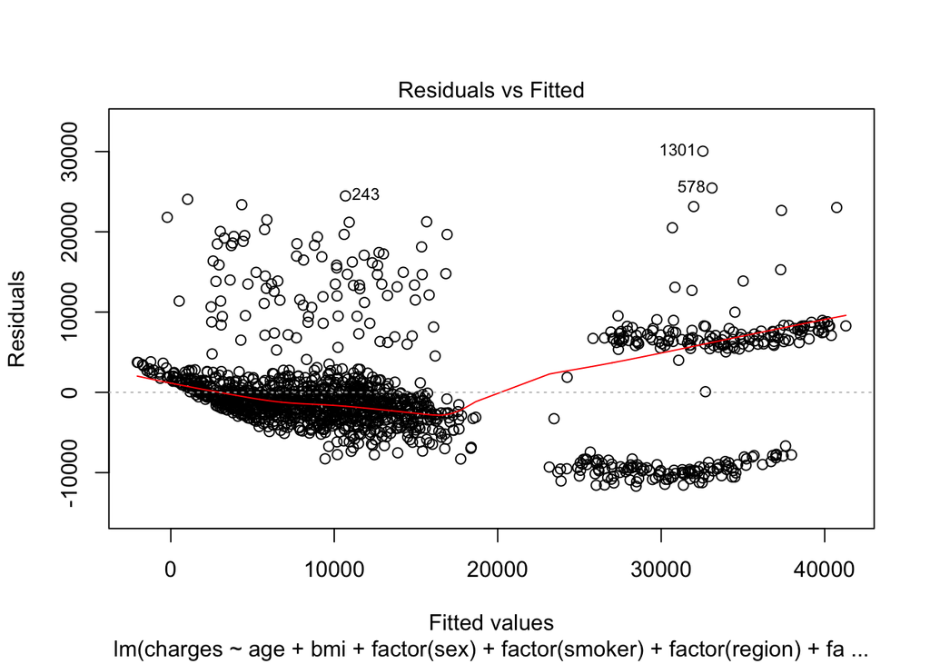

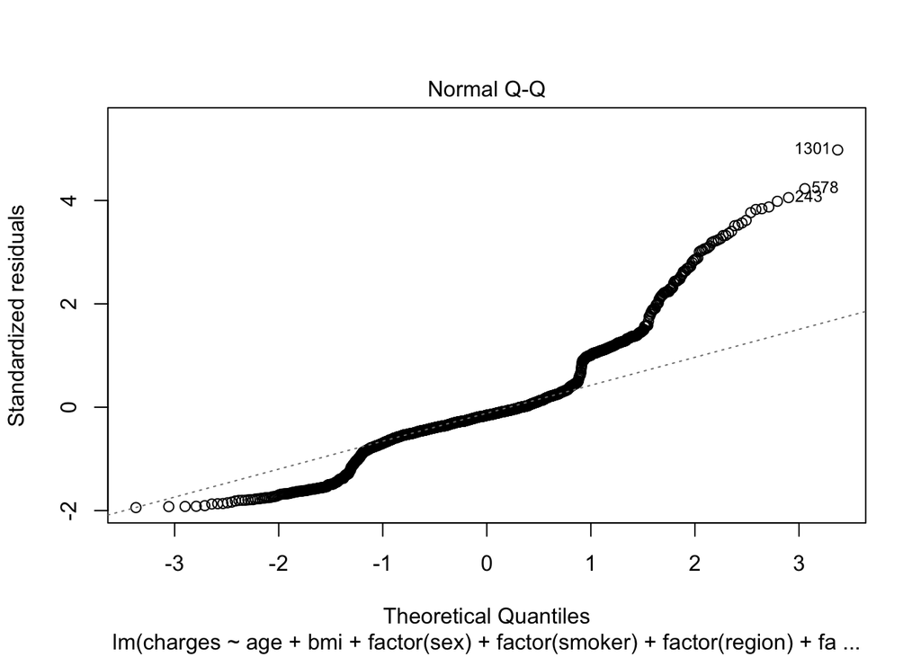

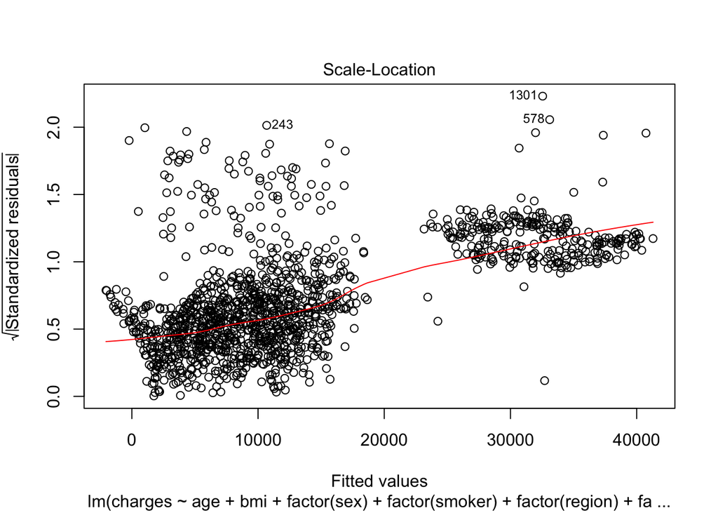

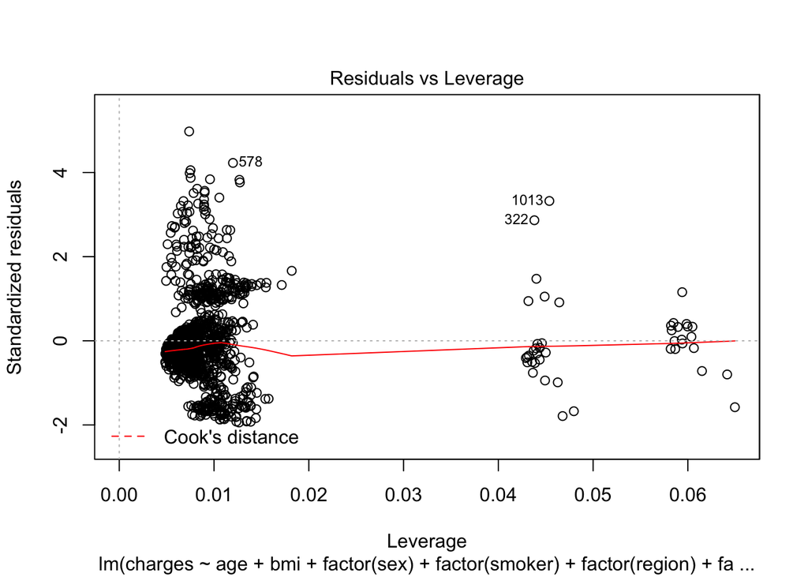